# PA1_template_.Rmd

Timothy M. Sims, Jr.

November 7, 2016

## Background

The purpose of this script or recipe is to complete the analysis of activity monitoring data. This data was collected leveraging a device that collects information in 5 minute intervals. This data was tracked over two months for an anonymour individuals during the months of October and November, 2012. A link to the data is provided below, as well as a desciption of the variables in the data set.

### Data Found Here

- **Dataset**: [Activity Data](https://d396qusza40orc.cloudfront.net/repdata%2Fdata%2Factivity.zip) [52K]

### Data Variables

- **steps**: The number of steps taken during a 5-minute interval; missing values = `NA`
- **date**: the date on which the measurement was taken: YYYY-MM-DD format
- **interval**: Identifier for the 5-minute interval in which measurement was taken

### Load Data

```r
### Load Data
activity <- read.csv("D:/data/data/activity.csv", stringsAsFactors=FALSE)
```

Let’s take a looked at the data now that is is loaded

**First**: Examine First 5 Observations

```r
### Examine Head
head(activity, n=5)
```

```
##   steps       date interval
## 1    NA 2012-10-01        0
## 2    NA 2012-10-01        5
## 3    NA 2012-10-01       10
## 4    NA 2012-10-01       15
## 5    NA 2012-10-01       20
```

**Second**: Examine Last 5 Observations

```r
### Examine Head
tail(activity, n=5)
```

```
##       steps       date interval
## 17564    NA 2012-11-30     2335
## 17565    NA 2012-11-30     2340
## 17566    NA 2012-11-30     2345
## 17567    NA 2012-11-30     2350
## 17568    NA 2012-11-30     2355
```

Notice the ‘NA’ values in the data. Let’s take a look at how many there are in the data.

**Third**: Check a Summary of the data.

```r
### Examine Summary of the Data
summary(activity)
```

```
##      steps            date              interval
##  Min.   :  0.00   Length:17568       Min.   :   0.0
##  1st Qu.:  0.00   Class :character   1st Qu.: 588.8
##  Median :  0.00   Mode  :character   Median :1177.5
##  Mean   : 37.38                      Mean   :1177.5
##  3rd Qu.: 12.00                      3rd Qu.:1766.2
##  Max.   :806.00                      Max.   :2355.0
##  NA's   :2304
```

**Fourth**: Check the Dimensions of the Data.

```r
### Examine Summary of the Data
dim(activity)
```

```
## [1] 17568     3
```

The `steps` variable shows mean of 37.38, a maximum of 806, and a minimum of 0. Of the 17,568 observations in the dataset, 2,304 are missing. This represents 13.11% of all observations in the dataset.

# What is the mean total number of steps taken per day?

## Objectives

- Make a histogram of the total number of steps taken each day.
- Calculate and report the mean and median total number of steps taken per day.

#### Ramp Up and Histogram Code

```r
### Load to dplyr to leverage power of summarise function, take advantage of
### magrittr package to make code more readable.
library(dplyr)
steps.per.day <- activity %>% group_by(date) %>% summarise(total = sum(steps, na.rm = T))

### Calculate the mean steps per day
mean.steps.per.day <- mean(steps.per.day$total)
mean.steps.per.day
```

```
## [1] 9354.23
```

```r
### Calculate the median steps per day
median.steps.per.day <- median(steps.per.day$total)
median.steps.per.day
```

```
## [1] 10395
```

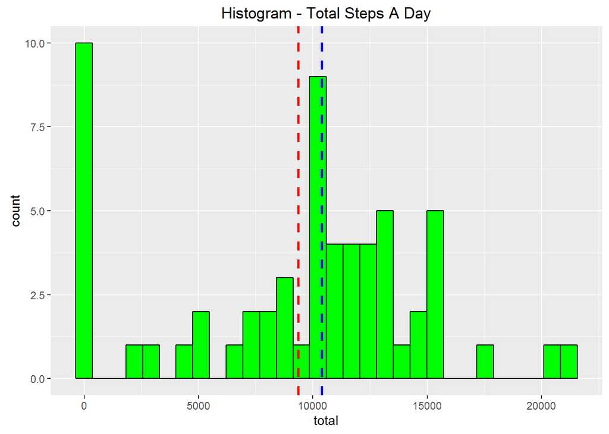

```r
### Load ggplot2 to generate breaktaking stunning visuals
library(ggplot2)

### Use geom_histogram to generate plot
ggplot(steps.per.day, aes(x = total)) +
        geom_histogram(fill = "green", colour = "black") +
        geom_vline(xintercept = mean.steps.per.day, color = "red", linetype = "dashed", size = 1) +
        geom_vline(xintercept = median.steps.per.day, color = "blue", linetype = "dashed", size = 1) +
        labs(title = "Histogram - Total Steps A Day")
```

### Analysis

The mean (denoted by dashed RED line) `steps` per day was *9354* for the time period of October 2012 and November 2012, while the median (denoted by dashed BLUE line) `steps` was *10395* over the same time. The histogram shows a high proportion of zero steps, this can easily be explained by someone potentially forgetting to put on the fitness tracker.

# What is the daily activity pattern?

## Objectives

- Make a time series plot (i.e. `type = “1”) of the 5-minute interval (x-axis) and the average number of steps taken, averaged across all days (y-axis).
- Which 5-minute interval, on average, across all the days is the dataset, contains the maximum number of steps?

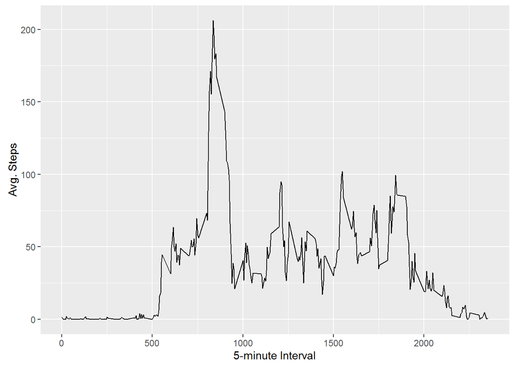

```r
### Leverage dplyr and magrittr packages to generate the average number of steps taken
### across all days for each 5-minute interval
avg.steps.per.int <- activity %>% group_by(interval) %>% summarise(avg.int = mean(steps, na.rm = T))

### Identify the Maximum average for the 5-minute interval. This interval will show
### which has the most activity, on average on any given day. Leverage which() function
### to identify the index at which avg.int is equal to the max avg.int
max.steps.int <- which(avg.steps.per.int$avg.int == max(avg.steps.per.int$avg.int))

### Pushing this index forward to indentify the interval at which this occurs, we leverage
### brackets to pull the approriate result to the forefront.
max.steps.inv <- avg.steps.per.int[max.steps.int, 1]

ggplot(avg.steps.per.int, aes(x = interval, y = avg.int)) +
        geom_line() +
        xlab("5-minute Interval") +
        ylab("Avg. Steps")
```

### Analysis

The highest 5-minutes interval `steps` average across all days is 206.17.

# Imputing Missing Values

## Objectives

- Calculate and report the total number of missing values in the dataset (i.e. the total number of rows with NA’s).

```r
activity.missing <- is.na(activity$steps)
table(activity.missing)
```

```
## activity.missing
## FALSE  TRUE
## 15264  2304
```

- Devise a strategy for filling in all of the missing values in the dataset. The strategy does not need to be sophisticated. For example, you could use the mean/median for that day, or the mean for that 5-minute interval, etc.
- Create a new dataset that is equal to the original dataset but with the missing data filled in.

```r
### Copy Original Dataset
filled.in.activity <- activity

### Iterate over the copied dataset to replace the missing values "NA" with the
### mean within hour. Median could also be used.
for (x in 1:nrow(filled.in.activity)) {
    ### if data is na, then complete these steps in the algorithm
    if (is.na(filled.in.activity[x, "steps"])) {
        ### Identify - for given x grab the interval that needs replaced
        interval.miss <- filled.in.activity[x, "interval"]
        ### Index - Match the Missing Interval with Appropriate Interval from avg.steps.per.int
        interval.miss.x <- which(avg.steps.per.int[, "interval"] == interval.miss)
        ### Exploit - Exploit the Index to populate the appropriate Mean
        steps.miss.mean <- avg.steps.per.int[interval.miss.x, "avg.int"]
        ### Execute - Populate the Mean to the dataset
        filled.in.activity[x, "steps"] <- steps.miss.mean
    }
}

### Check the dataset to see if all NA's have been removed
(nrow(filled.in.activity) - sum(complete.cases(filled.in.activity))) == 0
```

```
## [1] TRUE
```

- Make a histogram of the total number of steps taken each day and Calculate and report the mean and median total number of steps taken per day. Do these values differ from the estimates from the first part of the assignment? What is the impact of imputing missing data on the estimates of the total daily number of steps?

```r
### Load to dplyr to leverage power of summarise function, take advantage of
### magrittr package to make code more readable.
library(dplyr)
steps.per.day.filled <- filled.in.activity %>% group_by(date) %>% summarise(total = sum(steps, na.rm = T))

### Calculate the mean steps per day
mean.steps.per.day.filled <- mean(steps.per.day.filled$total)
mean.steps.per.day.filled
```

```
## [1] 10766.19
```

```r
### Calculate the median steps per day
median.steps.per.day.filled <- median(steps.per.day.filled$total)
median.steps.per.day.filled
```

```
## [1] 10766.19
```

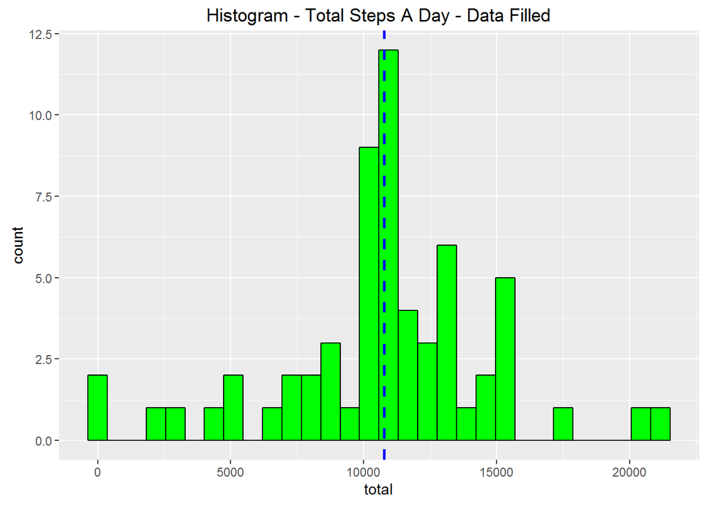

```r
### Use geom_histogram to generate plot
ggplot(steps.per.day.filled, aes(x = total)) +
        geom_histogram(fill = "green", colour = "black") +
        geom_vline(xintercept = mean.steps.per.day.filled, color = "red", linetype = "dashed", size = 1) +
        geom_vline(xintercept = median.steps.per.day.filled, color = "blue", linetype = "dashed", size = 1) +
        labs(title = "Histogram - Total Steps A Day - Data Filled")
```

# Are there differences in activity patterns between weekdays and weekends?

## Objectives

- Create a new factor variable in the dataset with two levels - “weekday” and “weekend” indicating whether a given date is a weekday or weekend day.

```r
### Create a function to evaluate whether or not the date is a weekend
day.eval <- function(date) {
    day <- weekdays(date)
    if (day %in% c("Monday", "Tuesday", "Wednesday", "Thursday", "Friday"))
        return("Weekday")
    else if (day %in% c("Saturday", "Sunday"))
        return("Weekend")
    else
        stop("invalid date")
}

filled.in.activity$date <- as.Date(filled.in.activity$date)
filled.in.activity$day.category <- sapply(filled.in.activity$date, FUN = day.eval)

### Examine to see if this code worked properly.
head(filled.in.activity, n=10)
```

```
##        steps       date interval day.category
## 1  1.7169811 2012-10-01        0      Weekday
## 2  0.3396226 2012-10-01        5      Weekday
## 3  0.1320755 2012-10-01       10      Weekday
## 4  0.1509434 2012-10-01       15      Weekday
## 5  0.0754717 2012-10-01       20      Weekday
## 6  2.0943396 2012-10-01       25      Weekday
## 7  0.5283019 2012-10-01       30      Weekday
## 8  0.8679245 2012-10-01       35      Weekday
## 9  0.0000000 2012-10-01       40      Weekday
## 10 1.4716981 2012-10-01       45      Weekday
```

- Make a panel plot containing a time series plot (i.e. type = “l”) of the 5-minute interval (x-axis) and the average number of steps taken, averaged across all weekday days or weekend days (y-axis). See the README file in the GitHub repository to see an example of what this plot should look like using simulated data.

```r
### Summarise data
filled.summary.data <- filled.in.activity %>% group_by(interval, day.category) %>%
    summarise(avg.steps = mean(steps))

### Examine the head of the function to see if it worked properly.
head(filled.summary.data, n=5)
```

```
## Source: local data frame [5 x 3]
## Groups: interval [3]
##
##   interval day.category  avg.steps
##      <int>        <chr>      <dbl>
## 1        0      Weekday 2.25115304
## 2        0      Weekend 0.21462264
## 3        5      Weekday 0.44528302
## 4        5      Weekend 0.04245283
## 5       10      Weekday 0.17316562
```

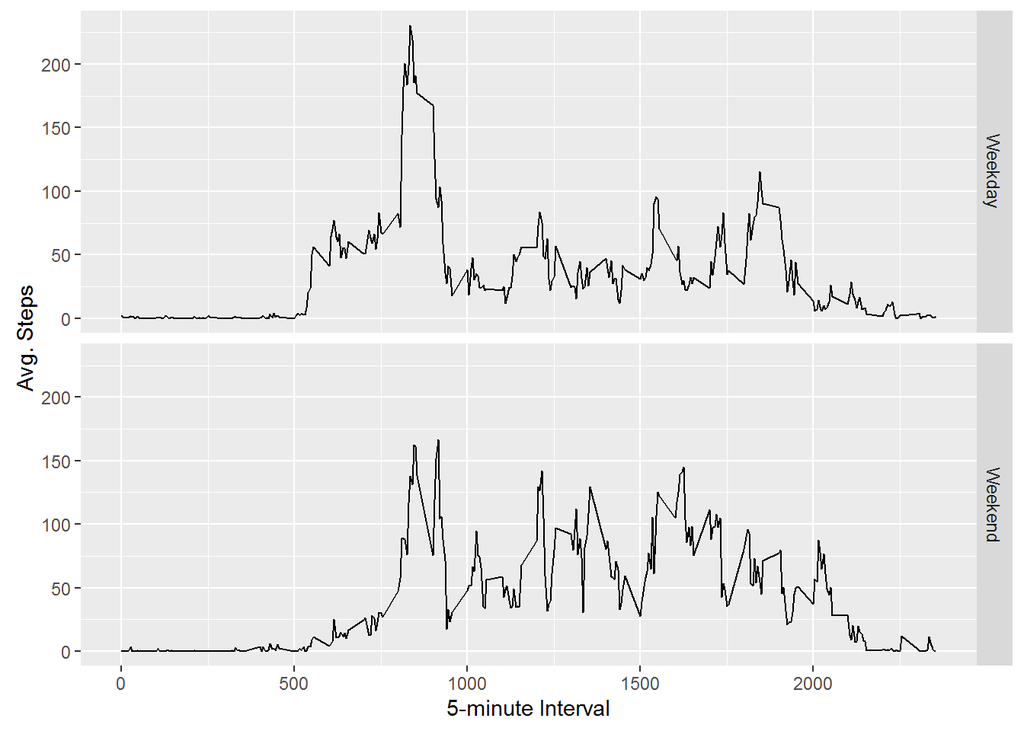

```r
ggplot(filled.summary.data, aes(x = interval, y = avg.steps)) +
        geom_line() +
        xlab("5-minute Interval") +
        ylab("Avg. Steps") +
        facet_grid(day.category~.)
```

### Analysis

Weekdays appear to have higher peaks, which probably correspond to a person traveling to work, whereas they may not leave home on the weekends. The average per 5 minute interval appears higher on the weekend might be the result of people being more active during their time off than sitting in their office.